# Lab4 - Normal Distribution

Keith Colella

2023-02-28

## Setup

```r
library(tidyverse)
library(openintro)
library(cowplot)
library(EnvStats)
library(nortest)
set.seed(101112)
```

This data set contains data on 515 menu items from some of the most popular fast food restaurants worldwide.

```r
data('fastfood', package='openintro')
head(fastfood)
```

```
## # A tibble: 6 × 17
##   restaur…¹ item  calor…² cal_fat total…³ sat_fat trans…⁴ chole…⁵ sodium total…⁶
##   <chr>     <chr>   <dbl>   <dbl>   <dbl>   <dbl>   <dbl>   <dbl>  <dbl>   <dbl>
## 1 Mcdonalds Arti…     380      60       7       2     0        95   1110      44
## 2 Mcdonalds Sing…     840     410      45      17     1.5     130   1580      62
## 3 Mcdonalds Doub…    1130     600      67      27     3       220   1920      63
## 4 Mcdonalds Gril…     750     280      31      10     0.5     155   1940      62
## 5 Mcdonalds Cris…     920     410      45      12     0.5     120   1980      81
## 6 Mcdonalds Big …     540     250      28      10     1        80    950      46
## # … with 7 more variables: fiber <dbl>, sugar <dbl>, protein <dbl>,
## #   vit_a <dbl>, vit_c <dbl>, calcium <dbl>, salad <chr>, and abbreviated
## #   variable names ¹restaurant, ²calories, ³total_fat, ⁴trans_fat,
## #   ⁵cholesterol, ⁶total_carb
```

```r
mcdonalds <- fastfood %>%
  filter(restaurant == 'Mcdonalds')
dairy_queen <- fastfood %>%
  filter(restaurant == 'Dairy Queen')
```

## Exercise 1

#### Question

Make a plot (or plots) to visualize the distributions of the amount of calories from fat of the options from these two restaurants. How do their centers, shapes, and spreads compare?

#### Response

```r
cat('No. observations for Mcdonalds:',nrow(mcdonalds),
    '\nNo. observations for Diary Queen:',nrow(dairy_queen),'\n')
```

```
## No. observations for Mcdonalds: 57
## No. observations for Diary Queen: 42
```

```r
fastfood %>%
  filter(restaurant == 'Mcdonalds' | restaurant == 'Dairy Queen') %>%
  select(cal_fat) %>%
  summary()
```

```
##     cal_fat
##  Min.   :   0.0
##  1st Qu.: 160.0
##  Median : 240.0
##  Mean   : 274.9
##  3rd Qu.: 320.0
##  Max.   :1270.0
```

The number of observations in for each restaurant is relatively low (~50 each), and calories from fat covers a wide range of values, from 0 to 1270. As a result, the distributions can appear “bumpy” if the binwidth is set too low.

So, I’ve included two plots, using the freqpoly geom, which allows us to view both restaurants together. The first plot uses wide bins to reduce “noise” and give a broad sense of the distribution. From this first plot, the center of each distribution appears roughly aligned, centering around ~200 calories.

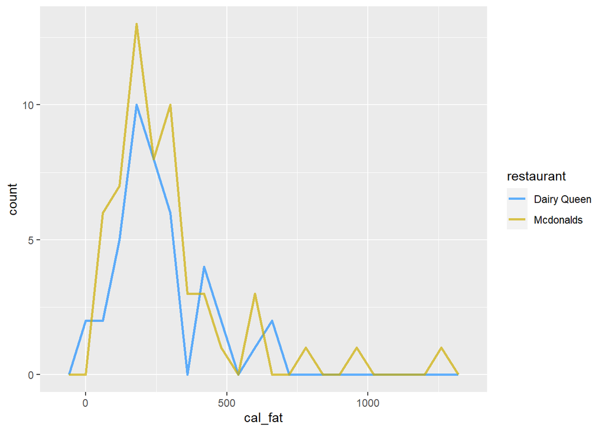

```r
fastfood %>%
  filter(restaurant == 'Mcdonalds' | restaurant == 'Dairy Queen') %>%
  ggplot(aes(x = cal_fat, color = restaurant)) +
  geom_freqpoly(binwidth = 60, linewidth = 1, alpha = 0.7) +
  scale_color_manual(values=c('dodgerblue','gold3'))
```

We can check this against the actual mean for each distribution.

```r
cat('Mean calories from fat for Mcdonalds:',
    mean(mcdonalds$cal_fat),
    '\nMean calories from fat for Dairy Queen:',
    mean(dairy_queen$cal_fat))
```

```
## Mean calories from fat for Mcdonalds: 285.614
## Mean calories from fat for Dairy Queen: 260.4762
```

This calculation reveals that the first plot is a bit misleading. In using wide bins to “smooth” the distribution, we lose some sense of the finer details.

This brings us to the second plot, which uses much smaller bins.

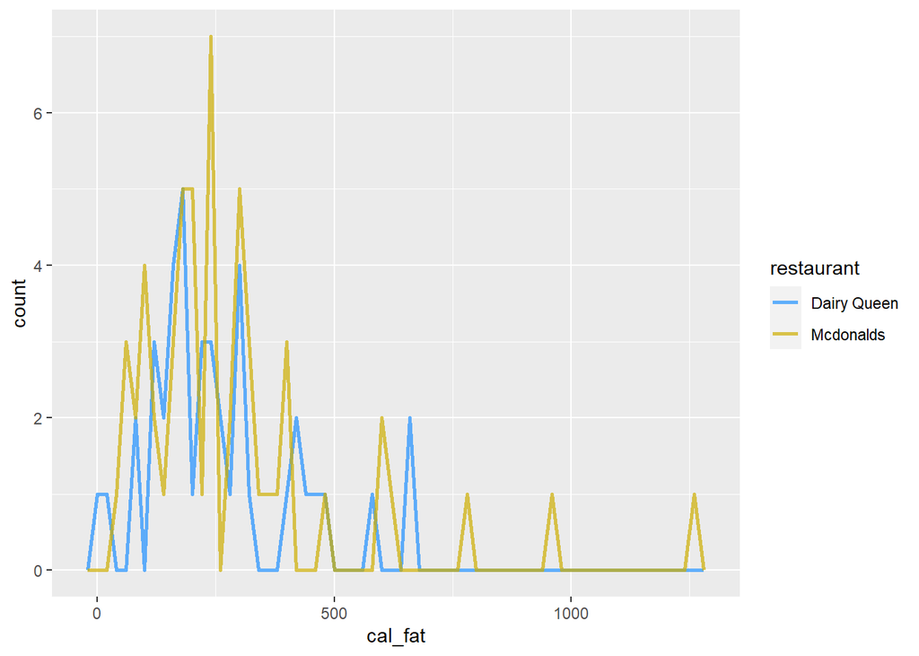

```r
fastfood %>%
  filter(restaurant == 'Mcdonalds' | restaurant == 'Dairy Queen') %>%
  ggplot(aes(x = cal_fat, color = restaurant)) +
  geom_freqpoly(binwidth = 20, linewidth = 1, alpha = 0.7)+
  scale_color_manual(values=c('dodgerblue','gold3'))
```

This plot gives a better sense of centrality, showing central tendency closer to ~250 calories, but it’s quite difficult to read, given the “bumpy”, multi-modal appearance.

In both plots, however, it’s clear that the Mcdonalds distribution has some significant outliers.